# Is enhancing certainty and severity of punishment associated with reducing crime rate?

MIDS W203, Fall 2018, Lab 3

Duda Espindola, Pri Nonis, Laura Pintos, Payman Roghani

```r
source('appendix.R')
```

# 1 Introduction

The primary motivation of this report is to provide causal estimates for determinants of crime in the state of North Carolina. The main aim of our study is to shape the public policy platforms of the political campaign that has hired our services, in the upcoming election cycle. We strive to provide actionable policy recommendations through motivated data analysis of the research question(s).

## 1.1 Research Question

Our research focuses on the following specific question: **Can enhancing the certainty and the severity of punishment reduce the crime rate?** We explore how certainty of punishment and severity of punishment within the criminal justice system affects crime. As one of the key goals of the political campaign is to reduce the crime rate, the natural choice for the outcome variable of our study is the Crime Rate variable. We seek to explain the variability of this variable using (1) Probability of Arrests, (2) Probability of Conviction, (3) Probability of Prison, and the (4) Average Prison Sentence. Toughness will be measured by the certainty of punishment based on the first three variables and the severity of punishment based on the fourth. Unfortunately, data for other forms of punishment is not available in our dataset and we will discuss their possible ommited bias on our model(s).

$$\begin{aligned}
\textbf{Crime Rate} & \sim \textbf{Probability of Arrest} \\
& + \textbf{Probability of Conviction} \\
& + \textbf{Probability of Prison} \\
& + \textbf{Average Prison Sentence}
\end{aligned}$$

We will primarily use these four explanatory variables as proxies to measure the effects of the the criminal justice system on crime and this relationship will be explored in our first OLS model. However, we expect other variables to have significant secondary effects on this relationship and thus, will further explore their impact in our extended second OLS model. In the third OLS model we will add more variables to the model to gauge the robustness of our choices for regressors.

## 1.2 Policy Hypothesis

The null hypothesis assumes that the outcome Crime Rate variable is not impacted by the four explanatory variables, Probability of Arrest, Probability of Conviction, Probability of Prison, and Average Prison Sentence. We will test the following hypothesis through our detailed data analysis to justify our ultimate policy recommendation(s).

- **Increasing arrest rates will decrease crime rate**
- **Increasing conviction rates will decrease crime rate**
- **Increasing prison verdicts will decrease crime rate**
- **Increasing prison sentence will decrease crime rate**

We will propose recommendations by finding robust, statistically significant, and practically significant regressors from our OLS models. We hope to either reject the null hypothesis by sufficiently explaining the variability of Crime Rate by our explanatory variables or explain why our model may does not support such a conclusion.

# 2 Data Loading and Cleaning

The primary data source for our study is **Cornwell and W. Trumball (1994), Estimating the Economic Model of Crime with Panel Data, Review of Economics and Statistics 76, 360-366**. We will use a single cross-section of data for **1987** from the multi-year panel. (The authors used panel data methods and instrumental variables to control for some types of omitted variables)

The dataset is provided for the year **1987** except for the **Percent Minority** (pctmin), which is provided for 1980.

## 2.1 Basic Sanity Checks

The dataset contained several technical defects such (1) as empty rows, (2) a duplicated row, and (3) a typo that prevented a numeric variable from being loaded correctly. These issues were easily corrected as shown below.

```r
crime           <- read.csv('crime_v2.csv') # load the dataset
rownames(crime) <- NULL                     # remove row names

crime           <- na.omit(crime)                          # (1) remove empty rows
crime           <- crime[!duplicated(crime$county),]       # (2) remove duplicate row
crime$prbconv   <- as.numeric(as.character(crime$prbconv)) # (3) fix non-numeric value

dim(crime)
```

```
## [1] 90 25
```

From the 100 counties of North Carolina our data-set contain a sample of **90** counties. The map below shows the Crime Rate per Capita for the 90 observations; the 10 counties that are not present in the dataset is shown in gray. The dataset contains **25** variables covering the following aspects. The **county** id is a subset of the U.S. Government’s FIPS County Code, the full 5-digit code can be constructed by combining the North Carolina FIPS prefix 37 with the **county** id which are the last three digits. For example, 37001 is Almanance County which is the first observation from our dataset with county id of 1.

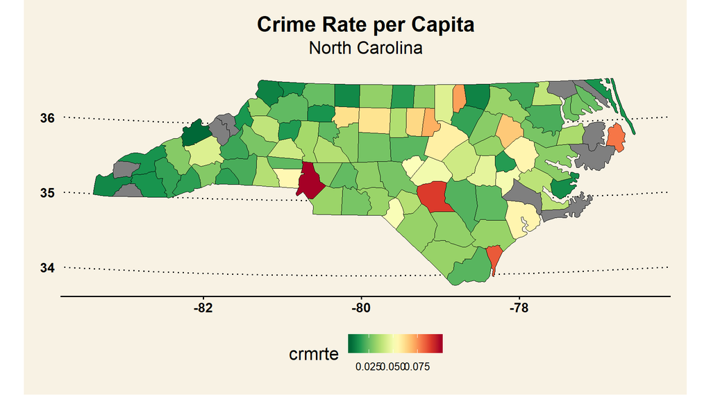

```r
mSetup(); mMapNC('crmrte', 'Crime Rate per Capita')
```

The missing counties appear to be geographically clustered to the western and eastern sides of North Carolina and gives reason to suspect the sample quality in terms of randomness, with respect to geographical clustering.

## 2.2 Deeper Analysis

We had to address various anomalies in the dataset, confirming if the values made sense based on the code key and understanding the outlying data points. We used a custom summary table to gleam a high level overview of the data for further analysis. We sorted the variables into four categories as follows.

```r
crime.summary <- sBuild(crime, crime$crmrte)
```

**Variable Categories**

- **Identification**

```r
sTable(crime.summary[c(1,2),]) # Identification
```

| Variable | CrimeCOR | Mean | Median | Min | Max | SD | Spread | Histogram |
| --- | --- | --- | --- | --- | --- | --- | --- | --- |
| county | 0.02 | 101 | 103 | 1 | 197 | 58 |  |  |
| year | NA | 87 | 87 | 87 | 87 | 0 |  |  |

- **Crime & Law Enforcement**

```r
sTable(crime.summary[c(3,4,5,6,7,8),]) # Crime & Law Enforcement
```

| Variable | CrimeCOR | Mean | Median | Min | Max | SD | Spread | Histogram |
| --- | --- | --- | --- | --- | --- | --- | --- | --- |
| crmrte | 1 | 0.03 | 0.03 | 0.01 | 0.1 | 0.02 |  |  |
| prbarr | -0.4 | 0.3 | 0.27 | 0.09 | 1.1 | 0.14 |  |  |
| prbconv | -0.39 | 0.55 | 0.45 | 0.07 | 2.1 | 0.35 |  |  |
| prbpris | 0.05 | 0.41 | 0.42 | 0.15 | 0.6 | 0.08 |  |  |
| avgsen | 0.02 | 9.7 | 9.1 | 5.4 | 21 | 2.8 |  |  |
| polpc | 0.17 | 0 | 0 | 0 | 0.01 | 0 |  |  |

- **Demographics & Geography**

```r
sTable(crime.summary[c(9,10,11,12,13,14,25),]) # Demographics & Geography
```

| Variable | CrimeCOR | Mean | Median | Min | Max | SD | Spread | Histogram |
| --- | --- | --- | --- | --- | --- | --- | --- | --- |
| density | 0.73 | 1.4 | 0.98 | 0 | 8.8 | 1.5 |  |  |
| taxpc | 0.45 | 38 | 35 | 26 | 120 | 13 |  |  |
| west | -0.35 | 0.24 | 0 | 0 | 1 | 0.43 |  |  |
| central | 0.17 | 0.38 | 0 | 0 | 1 | 0.49 |  |  |
| urban | 0.62 | 0.09 | 0 | 0 | 1 | 0.29 |  |  |
| pctmin80 | 0.18 | 26 | 25 | 1.3 | 64 | 17 |  |  |
| pctymle | 0.29 | 0.08 | 0.08 | 0.06 | 0.25 | 0.02 |  |  |

- **Weekly Wages**

```r
sTable(crime.summary[c(15,16,17,18,19,20,21,22,23),]) # Weekly Wages
```

| Variable | CrimeCOR | Mean | Median | Min | Max | SD | Spread | Histogram |
| --- | --- | --- | --- | --- | --- | --- | --- | --- |
| wcon | 0.39 | 285 | 281 | 194 | 437 | 48 |  |  |
| wtuc | 0.24 | 411 | 405 | 188 | 613 | 77 |  |  |
| wtrd | 0.43 | 211 | 203 | 154 | 355 | 34 |  |  |
| wfir | 0.34 | 322 | 317 | 171 | 509 | 54 |  |  |
| wser | -0.05 | 275 | 253 | 133 | 2177 | 207 |  |  |
| wmfg | 0.35 | 336 | 321 | 157 | 647 | 88 |  |  |
| wfed | 0.49 | 443 | 449 | 326 | 598 | 60 |  |  |
| wsta | 0.2 | 358 | 358 | 258 | 500 | 43 |  |  |
| wloc | 0.36 | 312 | 308 | 239 | 388 | 28 |  |  |

### 2.2.1 Probabilities Above 1

Theoretically speaking, we should not have probabilities over 1 (100%), but that is what we observe in variables Probability of Arrest (prbarr) and Probability of Conviction (prbconv). However, when we understand how those variables were proxied, we realize that they are not actual probabilities: they are simply ratios.

The probability of arrest is proxied by the ratio between the number of arrests in 1987 to the number of offenses in 1987. However, not every arrest made in 1987 might be referring to offenses made in 1987: there might be arrests referring to crimes committed in previous years, which explains why the ratio between arrests and offenses in 1987 could be above 1.

The probability of conviction is proxied by the ratio between the number of convictions and to the number of arrests in 1987. It is the same thing we have observed for the probability of arrest. The convictions issued in 1987 are not all necessarily referring to arrests made in 1987. Besides that, one arrest might lead to several convictions (example, a person arrested might be convicted for several crimes). In that sense, it is possible for us to have this variable achieving values above 1.

### 2.2.2 Outliers Off by Order of Magnitude

Another anomaly we observed, both by the histogram and by the summary statistics, is that for the density variable. There was a single value that is several orders of magnitude lower than other all other observations, with a density of 0.00002. We decided to investigate this further by using third party data sources.

```r
crime$county[crime$density<0.0001]
```

```
## [1] 173
```

Searching for the FIPS code of this county (37173), we see that it is Swain County. When we search the data for Swain County in 1987 in the United States Census Bureau database, we see that the density was in fact 0.202. Further, analysis of the variable indicates that there is a code key error and the density data is in fact **100s of people per sq. mile** and not number of people per sq. mile as it is stated. We corrected the arithmetic error for Swain County’s density to bring it in line with the other counties as shown below.

```r
crime$density[crime$county==173]<- crime$density[crime$county==173] * 10000
crime$density[crime$county==173]
```

```
## [1] 0.2
```

### 2.2.3 Other Significant Outliers

For the Service Industry Weekly Wages, there is one value that stands out as is significantly larger than the next largest value.

```r
crime$county[crime$wser>2000]
```

```
## [1] 185
```

Searching for the FIPS code of this county (37185), we see that it is Warren County. Coincidently only the service sector wages appear to be inflated for this county compared to the average weekly wages of all sectors across North Carolina. It is very likely this value was incorrectly multiplied by 10, and the actual value is 217.7 instead of 2177.1. However, since we cannot confirm that with certainty, we will leave it unmodified and not discard the observation.

# 3 Base Model

## 3.1 Model Specification

The study of our research question requires extended data analysis to choose the correct variables that identify the true relationship we are trying to model. The section below details the process of defining our base model. Our aim is to find the correct variables that can answers our already defined research question.

**Explained Variable**

Further analysis beyond our initial EDA is warranted on Crime Rate, the explained variable in our study.

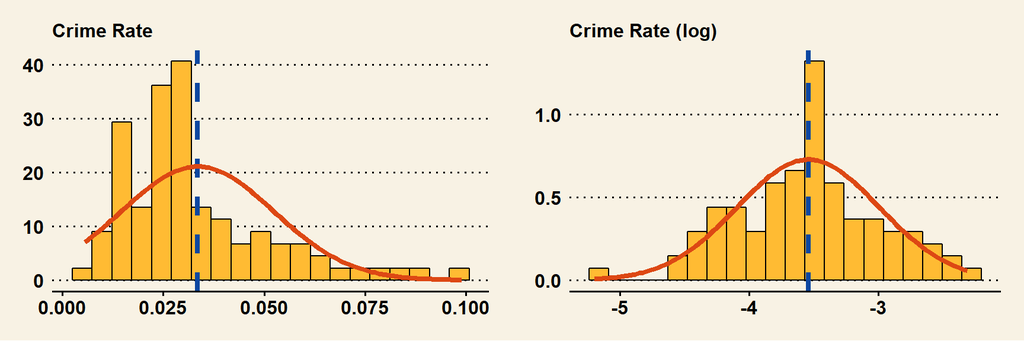

```r
p1 <- pHist(    crime$crmrte , breaks = 20, label = "Crime Rate"      )
p2 <- pHist(log(crime$crmrte), breaks = 20, label = "Crime Rate (log)")

plot_grid(p1, p2)
```

The crime rate histogram shows a significant positive skew in its distribution. Therefore, a log transformation of the variable allows the outlying data points to be pulled in closer to the bulk of the observations improving its normality. Furthermore, this improves the interpretability of the model by allowing us to explain effects from the regressors in terms of percent change on the regressand.

```r
crime$crmrte.log <- log(crime$crmrte) # log transformation
```

There is an extreme outlier on the left tail of the distribution, but we decided to keep that as we don’t have a strong reason for removing it.

**Explanatory Variables**

As discussed in the introduction, in order to test our hypothesis regarding the impact of the certainty and severity of punishment on crime rate, the following four explanatory variables will be used in the base model.

The sample of average sentence times in days in the dataset is not completely clear; one would assume prison sentences to be much longer. Possibly, this average includes convictions when no prison time was handed out. Regardless, for Average Prison Sentence to provide more interpretable results a log transformation is performed, so its effect could could be more easily reasoned in terms of a percent variation.

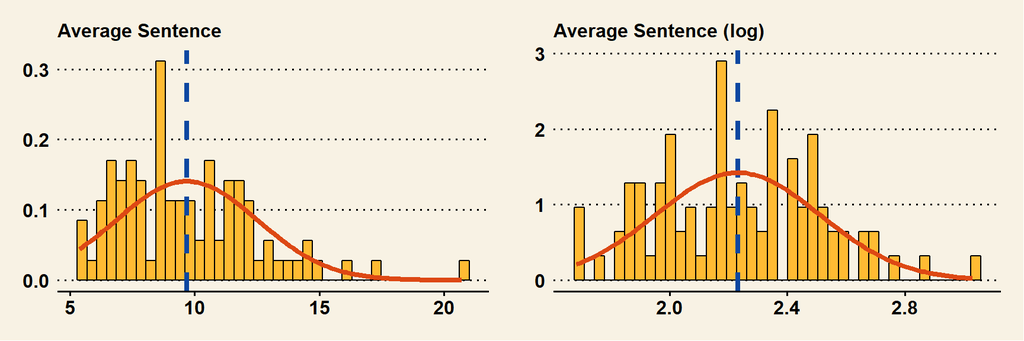

```r
p1 <- pHist(    crime$avgsen , breaks = 40, label = "Average Sentence"      )
p2 <- pHist(log(crime$avgsen), breaks = 40, label = "Average Sentence (log)")

plot_grid(p1, p2)
```

We do notice that there are some spikes and gaps in the distribution of the Average Prison Sentences. This could possibly be due to the determinant sentencing guideline that is in place in North Carolina, that mandates a fixed amount of time rather than a range of time.

```r
crime$avgsen.log <- log(crime$avgsen) # log transformation
```

County 115 consistently shows up in the histograms of crime rate, prbarr and prbconv as an extreme outlier. It has a low density (below first quartile), which could be the reason for the unusual values in our variables of interest.

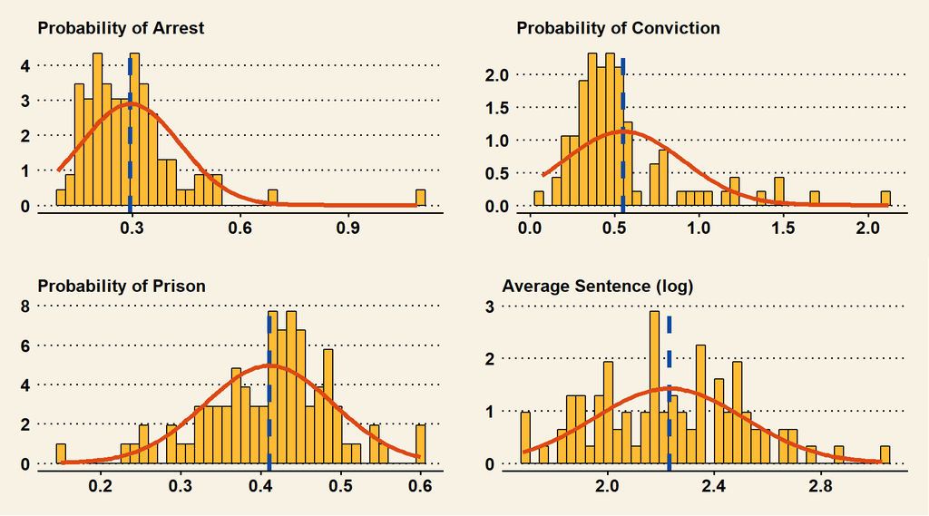

```r
p1 <- pHist(crime$prbarr,     breaks = 40, label = "Probability of Arrest"    )
p2 <- pHist(crime$prbconv,    breaks = 40, label = "Probability of Conviction")
p3 <- pHist(crime$prbpris,    breaks = 40, label = "Probability of Prison"    )
p4 <- pHist(crime$avgsen.log, breaks = 40, label = "Average Sentence (log)"   )

plot_grid(p1, p2, p3, p4)
```

Next, we looked at the scatterplots of dependent and explanatory variables for our base model. `prbarr` seems to have a pretty linear relationship with `crmrte.log`. The same with `prbconv`, although we see a curvature towards the right side of the chart. `prbpris` does not seem to have a linear relationship with `crmrte.log`, based on the scatterplot; it looks more like a quadratic relationship. However, we decided to leave `prbpris` as is, because a quadratic transformation would make the interpretation of our model unnecessarily complicated. `avgsen.log` also points toward a more quadratic relationship with `crmrte.log`, but making such further transformation to the avgsen variable (already logarithmically transformed), will damage the interpretability of our model, so we will leave `avgsen.log` as is.

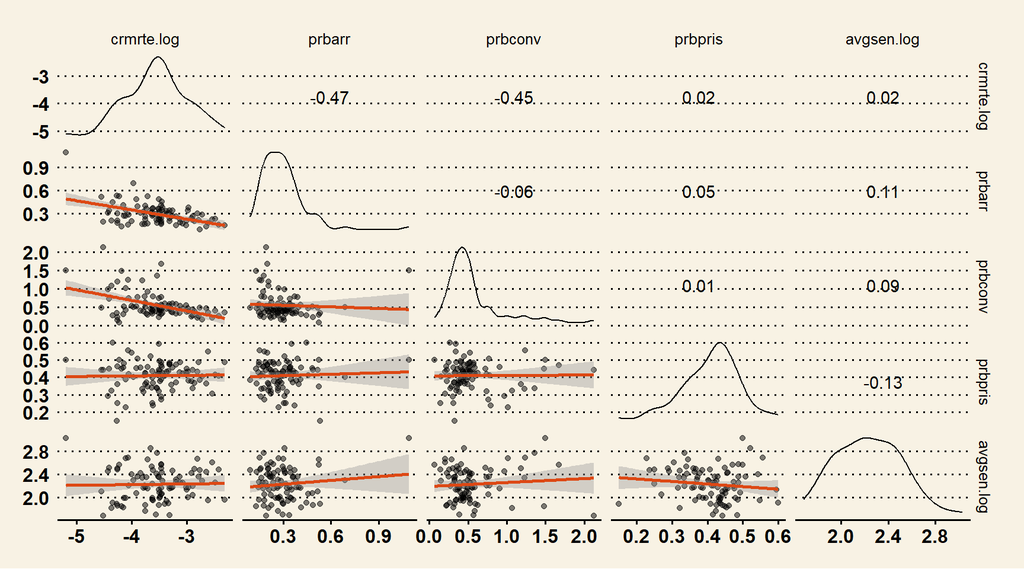

```r
pScatterMatrix(crime, columns = c(26,4,5,6,27))
```

**Specification**

Based on the variables selected, our base model is specified as follows.

```r
m1 <- lm(crmrte.log ~ prbarr     +
                      prbconv    +
                      prbpris    +
                      avgsen.log , data = crime)
```

## 3.2 Regression Analysis

We will evaluate the statistical significant of the model and assess its predicting power and practical significance with respect to our research question.

**Address CLM Assumptions**

1. **Linear in Parameters**

   Our model is linear in parameters as shown above, in the specification.
2. **Random (i.i.d) Sampling**

   We don’t have sufficient insight into how the data have been collected. For example, we don’t know if the probability of arrest is calculated by dividing the number of all arrests by the number all crimes across counties in 1987, or from a sample. But since the data are collected by key government agencies and used for analysis by reputable researchers, we assume random sampling. Another issue is that we don’t have data from some of counties and we are not sure how including additional data from those counties would affect our analysis. As a result, the insights from our regression modelling might not be applicable for the entire North Carolina, unless we have full insight into the missing data. An additional concern that we have with the sampling is that the data we have is only for year 1987. This specific year is know for the biggest crash in the stock market in one single day. If this event created specific conditions like an abnormal number of crime offenses (i.e. due to poverty, depression, anger, etc.) our sample is biased.
3. **No Perfect Multicollinearity**

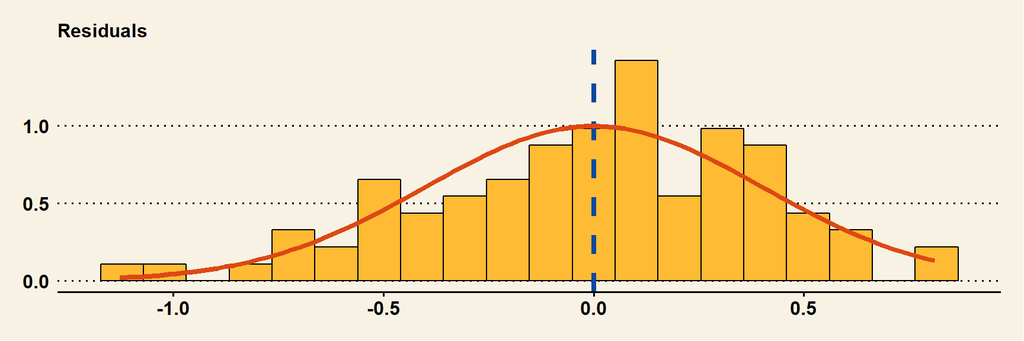

   ```r
   pHist(m1$residuals, breaks = 20, label = "Residuals")
   ```

**Coefficient Interpretation**

```r
coeftest(m1, vcov = vcovHC)
```

```
##
## t test of coefficients:
##
##             Estimate Std. Error t value Pr(>|t|)
## (Intercept)   -3.269      0.611   -5.35  7.3e-07 ***
## prbarr        -2.061      0.538   -3.83  0.00024 ***
## prbconv       -0.755      0.157   -4.81  6.5e-06 ***
## prbpris        0.456      0.644    0.71  0.48120
## avgsen.log     0.253      0.183    1.38  0.17130
## ---
## Signif. codes:  0 '***' 0.001 '**' 0.01 '*' 0.05 '.' 0.1 ' ' 1
```

It is worth noting that the coefficients for `prbarr` and `prbconv` amplify the effect of increasing `prbarr` or `prbconv`. This is not true for the coefficients for `prbpris` and `avgsen.log`. Another point worth noting is that, while `prbarr` and `prbconv` behave as we expected, `prbpris` and `avgsen.log` do not. An increase in those variables is associated with an increase in crime rates, the opposite of the effect we expected.

On the statistical significance, we can only reject that the true coefficients for Probability of Arrest and Probability of Conviction are zero. There is not enough evidence however, to support that the coefficients of Probability of Prison and Log(Average Sentence) are not zero.

It is worth noting that the coefficients for `prbarr` and `prbconv` amplify the effect of increasing `prbarr` or `prbconv`. This is not true for the coefficients for `prbpris` and `avgsen.log`.

**Goodness of Fit**

- The R-squared value for the base model is 0.467, which means around 47% of the variation in crime rate could be explained by our model.
- The adjusted R-square value for the base model is 0.442, and because it penalizes adding more variables, it is a better comparison indicator for our upcoming models, since the simple R-square can only go up when adding more variables.
- The Akaike Information Criterion value for the base model is 102, which we will compare with those of the next models to evaluate goodness of fit.

## 3.3 Research Interpretation

As evidenced by the coefficients of our base model, we can state that increases in probability of arrest and probability of conviction could potentially lower crime rate. In other words, a policy focused on more stringent arrest protocols and stricter criminal sentencing could be proposed by the political campaign. The probability of prison has a positive coefficient in our base model, meaning a higher prison to conviction ratio is associated with higher crime rate. We don’t believe this relationship means that, for example, if we increase the probability of prison, the crime rate will go up. We think that this might be due to the fact that the prison to conviction ratio is already high in areas where crime rate is high. For a more effective assessment of such a relationship, we need to have data to observe the trends in crime rate before and after the prison to conviction rate goes up as a result of policy change, which is not currently included in our dataset, which is snapshot of 1987. An additional possible explanation is that incarceration does not deter crime as it exposes the prisoners to an environment which could amplify their criminal behaviour when they finish their sentence. The log of average sentence has a positive coefficient in our base model, meaning issuing higher sentence times on average is associated with higher crime rate. However, we don’t believe this means that higher sentence times will drive the crime rate up. We understand this might be due to the nature of our dataset, focused in 1987 only. Maybe areas with higher crime rates simply naturally issued more sentences and higher sentence times, as a measure to inhibit crimes, however, the effect is yet to be noticed in the upcoming years.

# 4 Extended Model

## 4.1 Model Specification

This model attempts to improve upon the base model by incorporating additional explanatory variables. We will rely on our analysis of the base model to identify weaknesses in the selected regressors and identify possible covariates that could strengthen our prediction.

**Explained Variable**

The explained variable remains identical to the base model.

**Explanatory Variables**

To improve the predicting power, we decided to include two additional explanatory variables to our extended model. Below we explain the rationale for our decision.

- Police per Capita (`polpc`): We chose this covariate based on the assumption that a higher number of cops in charge would mean an unsafe environment for individuals to commit crimes, which in turn builds a safer, low-crime community. Therefore, we are expecting to observe a negative coefficient for this variable.
- Offense Mix (`mix`): A high offense mix value means a higher ratio of face-to-face offenses to other offenses. Since a face-to-face offense (e.g. assault, armed robbery, rape) often has at least a witness (except for homicide), we assume that probability of arrest is higher in such cases compared to other types of offenses. Also, face-to-face offenses are usually more serious that other types and could lead to higher likelihood of conviction and imprisonment as well as higher avg. sentence. Based on these assumptions, we are adding `mix` to the extended model, since it includes `prbarr`.

Having seen positive skewness in the distributions of `polpc` and `mix` in our in initial EDA and since none of these variables could take a negative value, we are considering log transformation of these variables. This is also appropriate since it mitigates the influence of positive outliers that we have identified in our data. As seen in the histograms below, since the log transformation results in distributions closer to normal for both `polpc` and `mix`, we decided to use log transformations of these variables in our model.

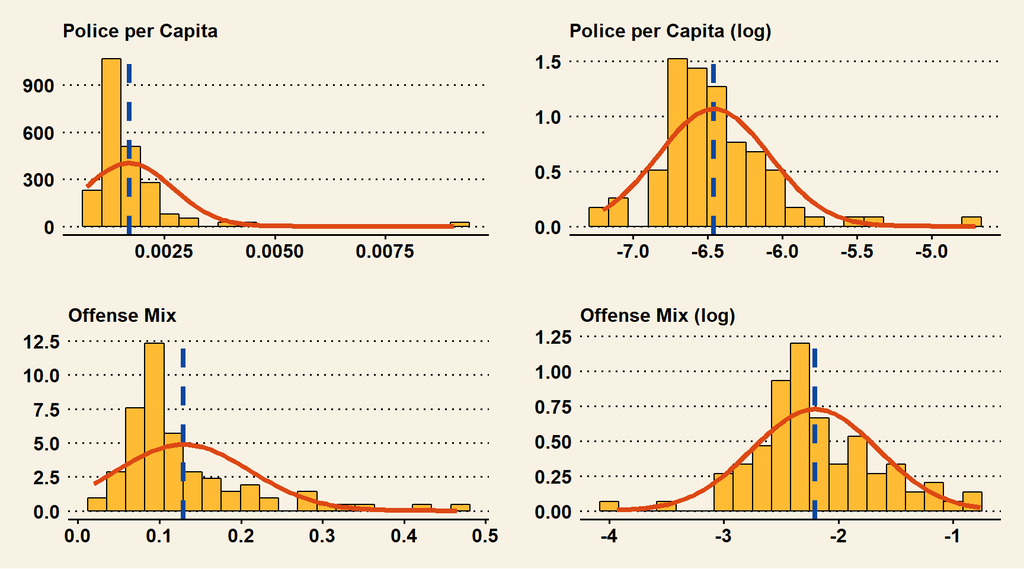

```r
p1 <- pHist(    crime$polpc , breaks = 20, label = "Police per Capita"         )
p2 <- pHist(log(crime$polpc), breaks = 20, label = "Police per Capita (log)"   )
p3 <- pHist(    crime$mix   , breaks = 20, label = "Offense Mix"               )
p4 <- pHist(log(crime$mix)  , breaks = 20, label = "Offense Mix (log)"         )

plot_grid(p1,p2,p3,p4)
```

```r
crime$polpc.log <- log(crime$polpc) # log transformation
crime$mix.log   <- log(crime$mix  ) # log transformation
```

Looking at the scatterplots of dependent and the additional explanatory variables for our second model, `polpc.log` and `mix.log` do not seem to have a linear relationship with the independent variable. Based on the scatterplots, quadratic transformation might be appropriate for `polpc.log` and `mix.log`, but it would make the interpretation of coefficients very complicated and difficult. Therefore, we will use the variables only with log transformation.

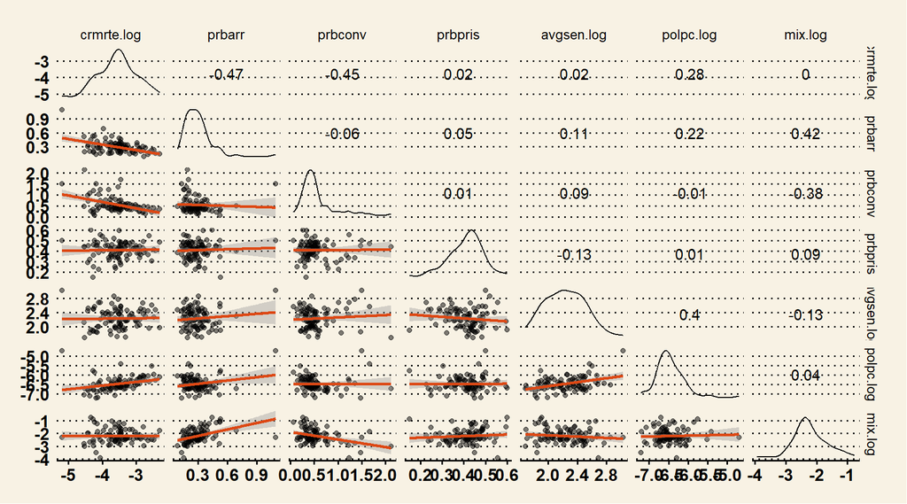

```r
pScatterMatrix(crime, columns = c(26,4,5,6,27,28,29))
```

**Specification**

Based on the variables selected, our extended model is specified as follows.

```r
m2 <- lm(crmrte.log ~ prbarr     +
                      prbconv    +
                      prbpris    +
                      avgsen.log +
                      polpc.log  +
                      mix.log    , data = crime)
```

## 4.2 Regression Analysis

We will evaluate the statistical significant of the model and assess its predicting power and practical significance with respect to our research question.

**Address CLM Assumptions**

1. **Linear in Parameters**

   Our model is linear in parameters.
2. **Random (i.i.d) Sampling**

   We don’t have sufficient insight into how the data have been collected. For example, we don’t know if the probability of arrest is calculated by dividing the number of all arrests by the number all crimes across counties in 1987, or from a sample. Another issue is that we don’t have data from some of counties and we are not sure how including additional data from those counties would affect our analysis. But since the data are collected by key government agencies and used for analysis by reputable researchers, we assume random sampling.
3. No Perfect Multicollinearity

   We did not identify any sign of perfect collinearity among our explanatory variables looking at the correlations. In addition, R would warn users if such collinearity exists, which did not happen throughout our analysis. This is confirmed by the low variance inflation factor (VIF) scores across model coefficients seen below.

   ```r
   vif(m2)
   ```

   ```
   ##     prbarr    prbconv    prbpris avgsen.log  polpc.log    mix.log
   ##        1.3        1.2        1.0        1.3        1.2        1.5
   ```

4. **Zero Conditional Mean**

   The residual vs fitted spline line is mostly flat, except for some curvature with a positive slope on the right side, deviating from zero, which might be due to the fact that we don’t have enough data points. The chart shows that the distribution of residuals around the zero line are not dependent on independent variables, and thus confirms that MLR assumption of Zero Conditional Mean.

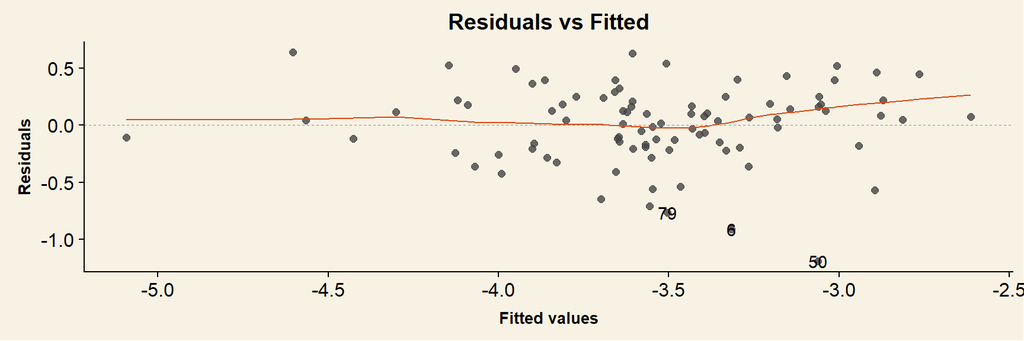

   ```r
   pDiagnostics(m2, which = 1)
   ```

5. **Homoscedasticity**

   Despite the fact that points on the Scale-Location chart seem to spread out as we move to the right (which is mostly because we have more points on the right side side), there doesn’t seem to be a strong sign of heteroskedasticity. To confirm this we also ran the Breusch-Pagan Test. Since the p-value **0.17** is greater than 0.05, the null hypothesis (absence of heteroskedasticity) can not be rejected. In other words there is no heteroskedasticity in our model (i.e. the variance of residuals are not dependent on the value of the fitted outcome variable). Nevertheless, we are using heteroskedasticity robust standard errors across our analysis to ensure unbiasedness of our estimators.

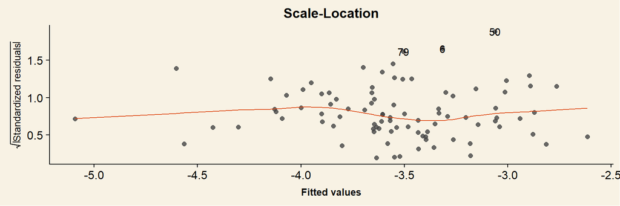

   ```r
   pDiagnostics(m2, which = 3)
   ```

   ```r
   bptest(m2)
   ```

   ```
   ##
   ##  studentized Breusch-Pagan test
   ##
   ## data:  m2
   ## BP = 9, df = 6, p-value = 0.2
   ```

6. **Normality**

   Even though the histogram of residuals does not show any significant skewness, we looked at the Normal Q-Q plot, which shows some deviations from the normal line on towards the 2 extremes of the normal line. Therefore, we ran the Shapiro-Wilk normality, which did not confirm this normality assumption (p-value < 0.05. That said, given the sample size we can assume normal sampling distribution in our model.

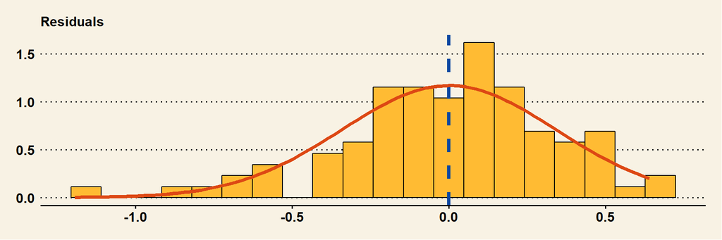

   ```r
   pHist(m2$residuals, breaks = 20, label = "Residuals")
   ```

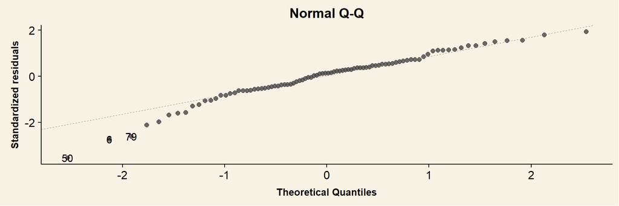

   ```r
   pDiagnostics(m2, which = 2)
   ```

   ```r
   shapiro.test(m2$residuals)
   ```

   ```
   ##
   ##  Shapiro-Wilk normality test
   ##
   ## data:  m2$residuals
   ## W = 1, p-value = 0.02
   ```

**Additional Model Diagnostics**

In order to identify potential high leverage points, we looked at the Residuals vs Leverage plot below. There seem to be a couple standardized residuals causing the deviation of the avg. line from zero on the right side; however, their Cook’s distance are smaller than 0.5, so we are not concerned about these points affecting our model.

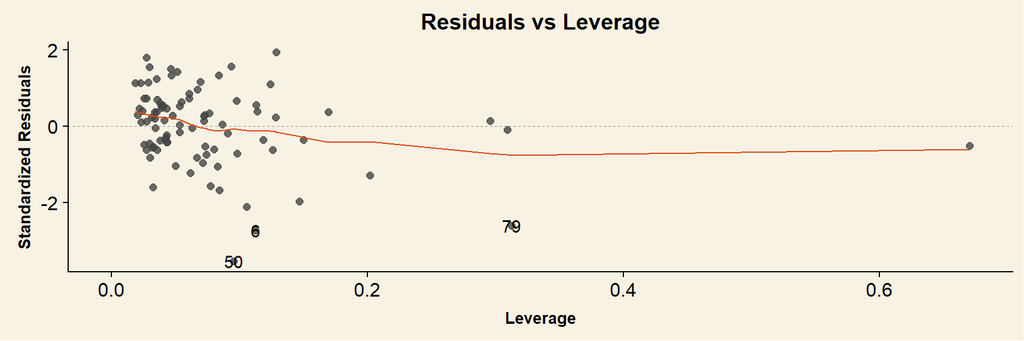

```r
pDiagnostics(m2, which = 5)
```

**Coefficient Interpretation**

```r
coeftest(m2, vcov = vcovHC)
```

```
##
## t test of coefficients:
##
##             Estimate Std. Error t value Pr(>|t|)
## (Intercept)   1.6729     1.4609    1.15     0.26
## prbarr       -2.4461     0.3338   -7.33  1.4e-10 ***
## prbconv      -0.7019     0.1186   -5.92  7.1e-08 ***
## prbpris       0.2835     0.7885    0.36     0.72
## avgsen.log   -0.0483     0.1950   -0.25     0.81
## polpc.log     0.6165     0.1390    4.44  2.8e-05 ***
## mix.log       0.0603     0.1152    0.52     0.60
## ---
## Signif. codes:  0 '***' 0.001 '**' 0.01 '*' 0.05 '.' 0.1 ' ' 1
```

**Goodness of Fit**

- The Adjusted R-squared value is **0.58**, which means around 58% of the variation in crime rate could be explained by our model. Since this is higher than the Adjusted R-squared for our base model(0.44), it means our extended model is a more accurate one.
- The Akaike Information Criterion value is **77.05**, which is lower than that of base model value 101.81. Again, this confirms that the extended model is more accurate than the base model.

## 4.3 Research Interpretation

As shown in the analysis above, our second model confirms what we found in our base model: increases in probability of arrest and probability of conviction are associated with lower crime rate. In other words, a policy focused on more stringent arrest protocols and stricter criminal sentencing could be proposed by the political campaign.

Even though an increase in avg. prison sentence is associated with lower crime rate, its coefficient is not statistically significant. This might be due to the fact that avg. prison sentence is pretty low across North Carolina (with maximum of around 20 days), which is unusual, since most prison sentences are at least a few months. Therefore, it is worth further evaluating this matter in the state, which is going to be part of our recommendation to the political campaign.

As in the base model, the probability of prison has a positive coefficient in our base model, meaning a higher prison to conviction ratio is associated with higher crime rate. Also, in model 2, we found that increase in police per capita is associated with higher crime rate. We believe that the relationships we observed might be due to the fact that the prison to conviction ratio and police per capita are already high in areas where crime rate is high. For a more effective assessment of this situation, we would have to have data to see the trends in crime rate before and after changes in prison/conviction ratio and police per capita where they are implemented.

# 5 Kitchen-sink Model

## 5.1 Model Specification

With this third specification, we do not expect to obtain the most **parsimonious model** that describes our population, and expect it to possibly be an **overfitting model**.

**Specification**

Based on the variables selected, our kitchen-sink model is specified as follows.

```r
m3 <- lm(crmrte.log ~ prbarr      +
                      prbconv     +
                      prbpris     +
                      avgsen.log  +
                      polpc.log   +
                      mix.log     +
                      density     +
                      taxpc       +
                      pctmin80    +
                      pctymle     +
                      wcon + wtuc + wtrd +
                      wfir + wser + wmfg +
                      wfed + wsta + wloc , data = crime)
```

## 5.2 Regression Analysis

We will evaluate the statistical significant of the model and use it to test the robustness of our extended model.

**Address CLM Assumptions**

1. **Linear in Parameters**

   The specification is linear in parameters.
2. **Random (i.i.d) Sampling**

   See our note for the base model.
3. **No Perfect Multicollinearity**

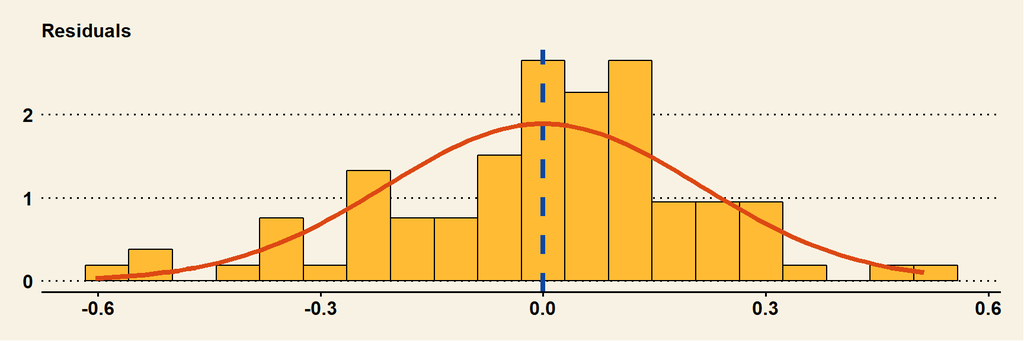

   ```r
   pHist(m3$residuals, breaks = 20, label = "Residuals")
   ```

**Coefficient Interpretation**

```r
coeftest(m3, vcov = vcovHC)
```

```
##
## t test of coefficients:
##
##              Estimate Std. Error t value Pr(>|t|)
## (Intercept) -1.31e+00   1.90e+00   -0.69  0.49483
## prbarr      -1.80e+00   2.52e-01   -7.13  7.4e-10 ***
## prbconv     -5.59e-01   1.56e-01   -3.57  0.00064 ***
## prbpris     -1.44e-01   5.26e-01   -0.27  0.78538
## avgsen.log  -5.85e-02   1.63e-01   -0.36  0.72094
## polpc.log    3.98e-01   1.82e-01    2.19  0.03201 *
## mix.log     -2.74e-02   9.88e-02   -0.28  0.78194
## density      8.31e-02   4.38e-02    1.90  0.06220 .
## taxpc        3.28e-03   7.79e-03    0.42  0.67519
## pctmin80     1.18e-02   1.93e-03    6.13  4.6e-08 ***
## pctymle      2.93e+00   1.75e+00    1.67  0.09935 .
## wcon         2.29e-04   7.44e-04    0.31  0.75895
## wtuc         9.34e-05   5.63e-04    0.17  0.86871
## wtrd         6.42e-04   1.59e-03    0.40  0.68793
## wfir        -1.28e-03   1.14e-03   -1.12  0.26512
## wser        -2.71e-04   1.69e-03   -0.16  0.87311
## wmfg        -2.46e-04   5.05e-04   -0.49  0.62715
## wfed         2.08e-03   1.11e-03    1.87  0.06609 .
## wsta        -1.29e-03   8.88e-04   -1.45  0.15059
## wloc         1.21e-03   2.20e-03    0.55  0.58454
## ---
## Signif. codes:  0 '***' 0.001 '**' 0.01 '*' 0.05 '.' 0.1 ' ' 1
```

**Goodness of Fit**

The values r-squared and r-squared adjusted are very high, this specification is probably an overfit model, too complicated for our data set and with too many regressors for our number of observations.

# 6 Regression Table

```r
stargazer(m1, m2, m3, type = "html", report = "vc", title = "Linear Models of Crime Rate",
          column.labels = c("M1", "M2", "M3"),
          keep.stat = c("rsq", "n"), omit.table.layout = "n",
          dep.var.labels = c("Crime Rate per Capita"), ci = T)
```

**Linear Models of Crime Rate**

|  | *Dependent variable:* |  |  |
| --- | --- | --- | --- |
|  | Crime Rate per Capita |  |  |
|  | M1 | M2 | M3 |
|  | (1) | (2) | (3) |
| prbarr | -2.100 | -2.400 | -1.800 |
| prbconv | -0.760 | -0.700 | -0.560 |
| prbpris | 0.460 | 0.280 | -0.140 |
| avgsen.log | 0.250 | -0.048 | -0.059 |
| polpc.log |  | 0.620 | 0.400 |
| mix.log |  | 0.060 | -0.027 |
| density |  |  | 0.083 |
| taxpc |  |  | 0.003 |
| pctmin80 |  |  | 0.012 |
| pctymle |  |  | 2.900 |
| wcon |  |  | 0.0002 |
| wtuc |  |  | 0.0001 |
| wtrd |  |  | 0.001 |
| wfir |  |  | -0.001 |
| wser |  |  | -0.0003 |
| wmfg |  |  | -0.0002 |
| wfed |  |  | 0.002 |
| wsta |  |  | -0.001 |
| wloc |  |  | 0.001 |
| Constant | -3.300 | 1.700 | -1.300 |
| Observations | 90 | 90 | 90 |
| R<sup>2</sup> | 0.470 | 0.610 | 0.850 |

# 7 Omitted Variable Analysis

Besides the variables presented to us in the crime dataset, we understand there are other variables that might impact both our explanatory variables and output variable. In this section we will discuss about the effects those variables might have in our model coefficients, theorizing whether their inclusion in the model would drive our coefficients away or closer to zero.

## 7.1 Illegal Guns per Capita (iguns)

This variable aims to measure the ratio of illegal guns to the population of the county. We expect that an increase on the number of illegal guns per person to be associated with a decrease in the probability of arrest, conviction, prison and the average sentence time, since they are harder to track to the owner, and therefore, provide enough evidence for making arrests, issuing convictions and convictions with prison time. Since the illegal purchase of a gun can be interpreted as a countermeasure to avoid future punishment, an increase on this variable can be interpreted as an increase on the intent of committing a crime, thus increasing the crime rates. Going with the same line of thought, an increase in this variable would be also associated with an increase on the mix variable, as crimes committed with guns are face-to-face crimes. However, we don’t expect the variation in this variable to be associated with variations in police per capita.

## 7.2 Average Education

Based on our background knowledge, we expect that more education will lead to a decrease on crime rates: a more educated population theoretically has better understanding of the law, is more tolerant and have better opportunities, so at least a decrease on pecuniary crimes and hate crimes are expected. By the same logic, more educated people, if commiting a crime, will tend to take some extra precautions in order to not get caught (being cautious in not generating evidence), leading to a decrease in the probability of arrest, probability of conviction, probability of arrest and average sentence time. We don’t expect it however to impact police per capita or the mix offenses variables.

## 7.3 Percent Poverty

We expect that higher levels of population below the poverty line might lead to a higher crime rate, as this population, being at risk, might resort to illegal means of income. We expect a positive correlation with probability of arrest, since the line of thought that the extreme poor might be more at risk to resorting to illegality, police may have them in watchlists, making an arrest easier when a crime is committed by that part of the population. Probability of conviction, probability of prison and average sentence times are also expected to be positively correlated to poverty, since they might have less access to good defense in courts, and also, judges might understand their condition as a risk factor to crime recidivism, being prone to issuing larger sentence times. We don’t expect it however to impact either police per capita or the mix of offenses.

## 7.4 Percent Addict

We understand that a population with higher incidences of substance abuse will tend to have higher crime rates, specially crimes motivated by emotional factors, as intoxicated people may not fully assess the consequences of their actions and react in violent ways. A positive correlation is also expected with probability of arrest and probability of conviction, as crimes committed by intoxicated people might be more related to violent reaction and not premeditated crimes, and they might not take any measures regarding concealing evidence to avoid getting caught. With more evidence, more likely they are to be arrested and convicted and associated with the nature of the crime committed, serving prison time, specially if the judge feels the substance abuse might lead them into crime recidivism. We also expect a positive correlation with the average sentence time, as the substance abuse might be considered aggravating circumstances, leading to higher sentence times. We don’t expect any relation with police per capita, but we feel there is a positive correlation with the mix offenses variable, since we previously stated that substance abuse might lead to violent reactions, and therefore, increasing the face-to-face offenses.

# 8 Conclusion

We started this study with the following research question: Is enhancing certainty and severity of punishment associated with reducing crime rate ?

The main conclusion we can take away from our analysis is that certainty of punishment is associated, however, severity of punishment is not.

The goal of the political campaign is to reduce crime rate. Our analysis is not a causal model, because we can’t measure (or even identify) all variables that might cause crime rate and these omitted variables might affect the results or our conclusions. Furthermore, we do not have data from subsequent years after implementing a crime policy change to causally confirm the effect.

Having said that, the probability of being arrested and convicted are associated with a lower crime rate. Therefore, we advice the political campaign to design policies that increase these probabilities.  
The political campaign should design policies focused on increasing the certainty of punishment (do criminals expect to get caught and convicted). We think that this can be accomplished with a strategy of publicity campaigns focused on increasing the “perception” of getting caught and convicted.

For example, investing in cameras/surveillance equipment that will be placed in hot spots in the counties, will probably conduct to more arrests (offenders identification) and convictions (the evidence will support the prosecutors cases). And therefore, the ratios used as probability proxies will increase. However, potential offenders do not check the proportion arrests to offenses when they go through the cost/benefit analysis of a criminal activity, they use their perception of being punished and probably rely on what has happened to relatives, acquaintances, etc that have conducted similar criminal activities. That is why we advise to develop publicity campaigns that should accompany each initiative. The campaigns will assure that a bigger segment of the population hears about the initiative and should have the effect to increase the perception of certainty of being punished, persuading the potential criminals to change their behaviour.

According to the results of our research, campaign focused more on the risk of apprehension and conviction, results of past police operations/crackdowns, etc, would have a better crime deterrent effect than informing of law changes that increase sentence time. Other example, if the police detects that criminals vandalize or break in cars in parking lots, a campaign threatening police apprehension for this type of crime would be effective.

**Other actionable insights could include**

- Invest in the police force modernization. The inclusion of cameras in public sites, for example, would increase the probability of arrest and would provide quality evidence to increase the probability of conviction.
- Increase the budget for police force training, this would result in a more efficient and effective police force, therefore increasing the probabilities of arrest and conviction
- Design policy focused on more stringent arrest protocols.

On the other hand, our research shows that probability of being sent to prison and time served in prison do not seem to predict a lower crime rate. Possible explanations are that prisons do not really rehabilitate, inmates learn new and better ways to commit crimes, are locked-up with bad influencers, and as such, more prison time could induce recidivism. Therefore we do not suggest the political campaign to explore policies associated with increasing sentence time.

Increasing the police per capita ratio or police force size does not decrease crime rate. This is not very intuitive and we think it could be due to the following reasons:

- The relationship might be inverse: counties with high crime rates tend to increase their police force, however, that increase is yet to achieve a result in crime reduction.
- Reporting of crimes: in counties with more police officers, people might feel more inclined to report the crimes, and the higher number of cops might also mean closer police stations for the population to report those crimes. That doesn’t necessarily mean that counties with less police have less crimes. It could instead mean that there is a great number of crimes that don’t get reported.

Having said that, increasing the number of police “in the streets” or in hot spots in the cities, would increase the perception of getting caught and would probably work as a deterrent effect on crime rate.

It is evident in the third model the association of percent of minorities with crime rate. The campaign should design crime prevention programs aimed at this demographic group (especially in counties with higher density).

**We suggest further research to include**  
* The data set does not discriminate among crime types. We suggest that further studies should be done discriminating violent crime (murder, rape, robbery etc.) from minor offenses such as property crimes (burglary, larceny, and auto theft). This could lead to more interesting findings on the specific effects of the predictor variables per type of crime. * The data set only includes data for the year 1987. We think that this sample could be biased. We would need to expand this research with more years. * Adding data on specific percent of minorities sub-groups, such as school dropouts, teenager parenting, substance abuse, could provide more actionable insights to design specific outreach programs.

# 9 Appendix

```r
# appendix.R

pModel <- function(m, title)
{
    autoplot(m, smooth.colour = "#dd4814", smooth.size = 1, alpha = 0.8, size = 2) +
    theme(title = element_text(size = 10, face = 'bold', family = 'sans'),
          plot.background = element_rect(fill = "#f8f2e4"))
}

pDiagnostics <- function(m, which)
{
    par(mfrow = c(1, 1))
    autoplot(m, which = which, ncol = 1, smooth.colour = "#dd4814", smooth.size = 1, alpha = 0.8, size = 2) +
        theme(title = element_text(size = 10, face = 'bold', family = 'sans'),
              plot.background = element_rect(fill = "#f8f2e4"))
}

pHist <- function(x, breaks, label)
{
    ggplot() +
    geom_histogram(aes(y = ..density.., x = x),
                   bins = breaks, fill = '#ffbb33', colour = '#000000') +
    geom_vline(xintercept = mean(x),
               linetype = 'dashed', size = 1.5, colour = '#0d47a1') +
    stat_function(aes(x = x), fun = dnorm, colour = '#dd4814',
                  size = 1.5, args = list(mean = mean(x), sd = sd(x))) +
    ggtitle(label) + theme_wsj() +
    theme(title = element_text( size = 10, face = 'bold', family = 'sans'),
          plot.background = element_rect(fill = "#f8f2e4"))
}

pScatterMatrix <- function(data, columns)
{
    ggscatmat(data, columns = columns, alpha = 0.5) +
    geom_smooth(method = 'lm', colour = '#dd4814') + theme_wsj()
}

mSetup <- function()
{
    cfips           <<- county.fips[grepl('north carolina', county.fips$polyname),]
    cfips           <<- rename(cfips, county = fips, subregion = polyname)
    cfips$county    <<- cfips$county - 37000
    cfips$subregion <<- gsub('north carolina,(.*?)', '\\1', cfips$subregion)
    cfips$subregion <<- gsub(':.*','',cfips$subregion)
    cfips           <<- cfips[!duplicated(cfips$subregion),]
    rownames(cfips) <<- NULL

    ncmap           <<- subset(map_data('county'), region == 'north carolina')
    ncmap           <<- left_join(ncmap, cfips, by = 'subregion')
    rownames(ncmap) <<- NULL
    ncmap           <<- left_join(ncmap, crime, by = 'county')
}

mMapNC <- function(column, title)
{
    ggplot(data = ncmap,
           mapping = aes_string(x = 'long', y = 'lat', group = 'group', fill = column)) +
    geom_polygon(color = 'black', size = 0.025) +
    coord_map(projection = 'albers', lat0 = 39, lat1 = 45) + theme_wsj() +
    theme(legend.position = 'bottom',
          text = element_text(size = 12, family = 'sans'),
          title = element_text(size = 16, family = 'sans'),
          plot.title = element_text(hjust = 0.5),
          plot.subtitle = element_text(hjust = 0.5)) +
    ggtitle(title, subtitle = 'North Carolina') +
    scale_fill_gradientn(colors = rev(brewer.pal(11, 'RdYlGn')))
}

sBuild <- function(dat,out){
    tbl_df(t(sapply(1:ncol(dat), function(n){
        x <- crime[,n]
        c(  Variable =   colnames(dat)[n], CrimeCOR  = round(cor(out,x), 2),
            Mean     = round( mean(x), 2), Median    = round( median(x), 2),
            Min      = round(  min(x), 2), Max       = round(    max(x), 2),
            SD       = round(   sd(x), 2),
            Spread   = list(x),
            Histogram = list(hist(x, plot = F)$counts))
    })))
}

sTable <- function(tab){
    formattable(tab, list(CrimeCOR = color_bar('#33b5e5'), SD = color_bar('#ff8800'),
                          Spread = function(z){
                              sapply(z, function(zz){
                                  knit(text = sprintf('`r sparkline(c(%s), type="box")`',
                                                      paste0(zz, collapse = ',')), quiet = T)})},
                          Scatter = function(z){
                              sapply(z, function(zz){
                                  knit(text = sprintf('`r sparkline(c(%s), type="line", fillColor=F)`',
                                                      paste0(zz, collapse = ',')), quiet = T)})},
                          Histogram = function(z){
                              sapply(z, function(zz){
                                  knit(text = sprintf('`r sparkline(c(%s), type="bar")`',
                                                      paste0(zz, collapse = ',')), quiet = T)})}
    ))
}

import <- function(package)
{
    if(!require(package, character.only = T))
        suppressWarnings(install.packages(package, dep = T))
    suppressWarnings(library(package, character.only = T))
}
```